# Importing libraries

```python
import pandas as pd
import numpy as np
import datetime as dt
import seaborn as sns
import matplotlib.pyplot as plt

from vnstock import *

from sklearn import metrics
from sklearn.model_selection import train_test_split
from sklearn.ensemble import RandomForestRegressor
from sklearn.preprocessing import StandardScaler
from sklearn.model_selection import RandomizedSearchCV
```

# EDA

Extract all data of FPT stock that is available (up to 04/17/2023 at this point of the project).

```python
df =  stock_historical_data(symbol='FPT',
                            start_date="2006-12-13",
                            end_date='2023-04-17')
df.set_index("TradingDate",inplace = True)

df.head()
```

| TradingDate | Open | High | Low | Close | Volume |
| --- | --- | --- | --- | --- | --- |
| 2006-12-14 | 16495.0 | 16495.0 | 16495.0 | 16495.0 | 280710 |
| 2006-12-15 | 17320.0 | 17320.0 | 17320.0 | 17320.0 | 265300 |
| 2006-12-18 | 18184.0 | 18184.0 | 18184.0 | 18184.0 | 215790 |
| 2006-12-19 | 19087.0 | 19087.0 | 19087.0 | 19087.0 | 137520 |
| 2006-12-20 | 20030.0 | 20030.0 | 20030.0 | 20030.0 | 220120 |

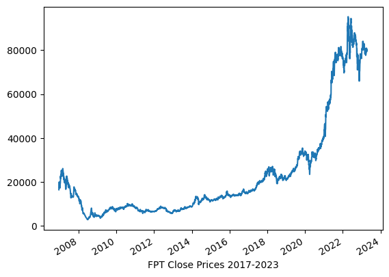

```python
df['Close'].plot()
plt.xlabel("FPT Close Prices 2017-2023")
plt.show()
```

The price movement of the stock went sideway from 2006-2020, but then went up drastically in the period of 2020-2022. If we use historical data to predict the stock price, the data from 2006-2020 would potentially train the model to predict the stock to go sideway, not uptrending as of now. Therefore, I reduced the sample to only include observations from 2020-2022 period.

```python
df =  stock_historical_data(symbol='FPT',
                            start_date="2020-01-01",
                            end_date='2023-04-17')
df.set_index("TradingDate",inplace = True)

df.head()
```

| TradingDate | Open | High | Low | Close | Volume |
| --- | --- | --- | --- | --- | --- |
| 2020-01-02 | 33874.0 | 34281.0 | 33700.0 | 34049.0 | 896720 |
| 2020-01-03 | 34223.0 | 34339.0 | 33351.0 | 33467.0 | 2047880 |
| 2020-01-06 | 33177.0 | 33467.0 | 33003.0 | 33119.0 | 1091660 |
| 2020-01-07 | 33293.0 | 33758.0 | 33119.0 | 33758.0 | 837240 |
| 2020-01-08 | 33409.0 | 33526.0 | 33003.0 | 33003.0 | 1814290 |

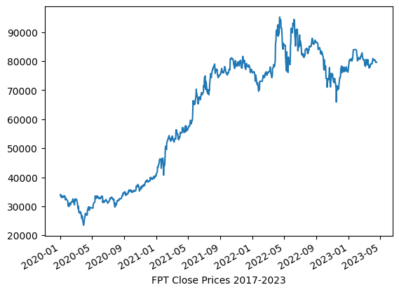

```python
df['Close'].plot()
plt.xlabel("FPT Close Prices 2017-2023")
plt.show()
```

On the 2020-2023 period, the stock showed upward trending, but slowed down towards the recent years.

[figure not shown]

```python
df['Close'].pct_change().plot.hist(bins = 50)
plt.xlabel("Closed 1 day percentage change")
plt.show()
```

The stock changes mostly around 0.01% on a trading day, which shows that the stock is not volatile, but more of a stable stock for long-term investment.

```python
df.isna().sum() # Checking for missing values.
```

```
Open      0
High      0
Low       0
Close     0
Volume    0
dtype: int64
```

# Modelling

First, we will try to apply Random Forest Modelling to our data.

#### Feature selection

Closing price will be our decision variable, and Open, High, Low, and Volume would be our independent variables for our model.

```python
x = df.drop('Close',axis = 1)
y = df['Close']
```

#### Training and testing

```python
x_train, x_test, y_train, y_test = train_test_split(x, y, test_size=0.2,  random_state=0)
```

Standardizing the variables as needed for the model.

```python
scale = StandardScaler()
x_train = scale.fit_transform(x_train)
x_test = scale.transform(x_test)
```

#### Fitting the model

```python
rf = RandomForestRegressor()
rf.fit(x_train, y_train)
```

```
RandomForestRegressor()
```

Perform hyperparameter tuning for our Random Forest Model. I set a grid search to find the optimal parameters, with 3 folds for each of 200 candidates.

```python
grid_rf = {
'n_estimators': [20, 50, 100, 500, 1000],
'max_depth': np.arange(1, 15, 1),
'min_samples_split': [2, 10, 9],
'min_samples_leaf': np.arange(1, 15, 2, dtype=int),
'bootstrap': [True, False],
'random_state': [1, 2, 30, 42]
}
rscv = RandomizedSearchCV(estimator=rf, param_distributions=grid_rf, cv=3, n_jobs=-1, verbose=2, n_iter=200)
rscv_fit = rscv.fit(x_train, y_train)
best_parameters = rscv_fit.best_params_
print(best_parameters)
```

```
Fitting 3 folds for each of 200 candidates, totalling 600 fits
{'random_state': 42, 'n_estimators': 20, 'min_samples_split': 2, 'min_samples_leaf': 1, 'max_depth': 13, 'bootstrap': True}
```

```python
model = RandomForestRegressor(n_estimators=500, random_state=2, min_samples_split=2, min_samples_leaf=1, max_depth=14, bootstrap=True)
model.fit(x_train, y_train)
predict = model.predict(x_test)
predictions = pd.DataFrame({"Predictions": predict}, index=pd.date_range(start=df.index[-1], periods=len(predict), freq="D"))
```

#### Ploting our prediction

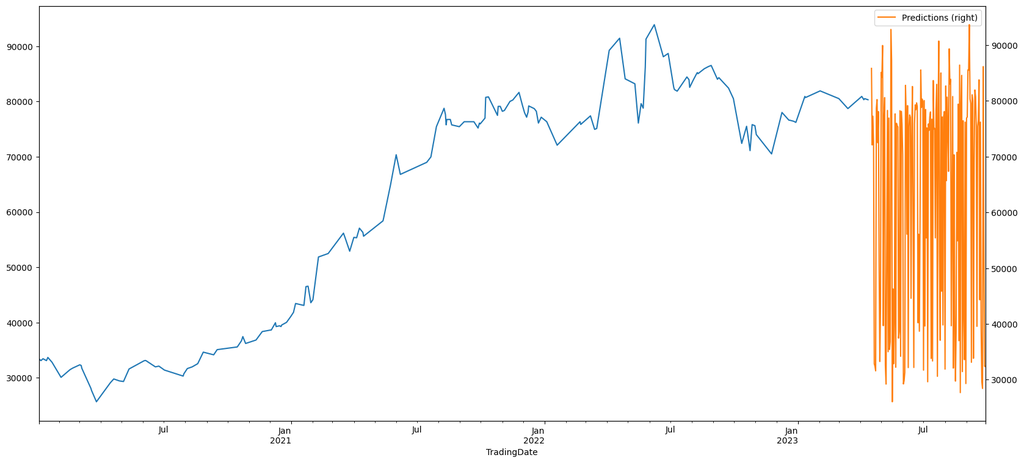

```python
fig, ax = plt.subplots(figsize=(20,10))
y_test.plot(ax=ax)
predictions.plot(ax=ax, secondary_y=True)
```

```python
print("Mean Absolute Error:", round(metrics.mean_absolute_error(y_test, predict), 4))
print("Mean Squared Error:", round(metrics.mean_squared_error(y_test, predict), 4))
print("Root Mean Squared Error:", round(np.sqrt(metrics.mean_squared_error(y_test, predict)), 4))
print("(R^2) Score:", round(metrics.r2_score(y_test, predict), 4))
print(f'Train Score : {model.score(x_train, y_train) * 100:.2f}% and Test Score : {model.score(x_test, y_test) * 100:.2f}% using Random Tree Regressor.')
errors = abs(predict - y_test)
mape = 100 * (errors / y_test)
accuracy = 100 - np.mean(mape)
print('Accuracy:', round(accuracy, 2), '%.')
```

```
Mean Absolute Error: 465.5485
Mean Squared Error: 469794.5133
Root Mean Squared Error: 685.4156
(R^2) Score: 0.9989
Train Score : 99.98% and Test Score : 99.89% using Random Tree Regressor.
Accuracy: 99.24 %.
```

```python
oneyear_df = pd.DataFrame(predictions[:252])
```

```
Buy price and date
            Predictions
2023-05-17    26037.882
Sell price and date
            Predictions
2023-09-05    93660.216
```

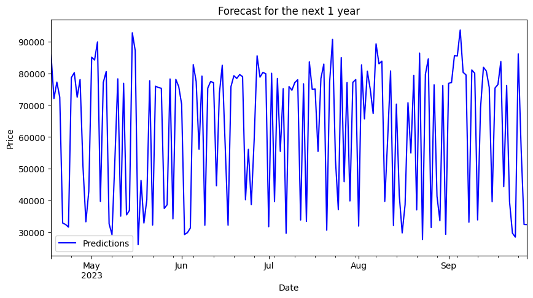

```python
buy_price = min(oneyear_df["Predictions"])
sell_price = max(oneyear_df["Predictions"])
oneyear_buy = oneyear_df.loc[oneyear_df["Predictions"] == buy_price]
oneyear_sell = oneyear_df.loc[oneyear_df["Predictions"] == sell_price]
print("Buy price and date")
print(oneyear_buy)
print("Sell price and date")
print(oneyear_sell)
oneyear_df["Predictions"].plot(figsize=(10, 5), title="Forecast for the next 1 year", color="blue")
plt.xlabel("Date")
plt.ylabel("Price")
plt.legend()
plt.show()
```

Our model indicates that we should buy at 26,000 VND and sell at 93,660 VND. However, this is not realistic as the stock price would rarely (if not never) drop to near 25,000 VND at this point. The problem with this forecasting model is it takes the entire observations in our dataset into consideration when predicting prices, therefore predicted price would fluctuate between the lowest point and the highest point of our sample.

That gives me an idea that our model should train to predict a future price only based on price actions of a few previous dates, not the entire dataset.

# Modify our approach

```python
df =  stock_historical_data(symbol='FPT',
                            start_date="2020-01-01",
                            end_date='2023-04-17') [['TradingDate','Close']]

df.index = df.pop('TradingDate')
df
```

| TradingDate | Close |
| --- | --- |
| 2020-01-02 | 34049.0 |
| 2020-01-03 | 33467.0 |
| 2020-01-06 | 33119.0 |
| 2020-01-07 | 33758.0 |
| 2020-01-08 | 33003.0 |
| ... | ... |
| 2023-04-11 | 80300.0 |
| 2023-04-12 | 80300.0 |
| 2023-04-13 | 79600.0 |
| 2023-04-14 | 79600.0 |
| 2023-04-17 | 79600.0 |

821 rows × 1 columns

For this particular approach, I will use the 7, 14, and 20-moving averages (MA) of the stock as the inputs for our model. Also, I will switch to LSTM model, as it is more commonly use in forecasting stocks with better sensitivity.

```python
def compute_moving_averages(df, n_list): # function that returns the moving average prices
    mas_dict = {f"MA{n}": [] for n in n_list}
    dates, close_prices = [], []
    for i in range(max(n_list)-1, len(df)):
        mas = [np.nanmean(df['Close'].iloc[i-n+1:i+1]) for n in n_list]
        for j, n in enumerate(n_list):
            mas_dict[f"MA{n}"].append(mas[j])
        dates.append(df.index[i])
        close_prices.append(df.loc[df.index[i], 'Close'])
    df_ma = pd.DataFrame(mas_dict, index=pd.to_datetime(dates))
    df_ma['Close'] = close_prices
    return df_ma.dropna()
```

```python
n_list = [7, 14, 20]
df_ma = compute_moving_averages(df, n_list)
df_ma
```

|  | MA7 | MA14 | MA20 | Close |
| --- | --- | --- | --- | --- |
| 2020-02-05 | 31043.571429 | 32189.071429 | 32575.50 | 30214.0 |
| 2020-02-06 | 30885.857143 | 32027.214286 | 32430.20 | 31143.0 |
| 2020-02-07 | 30620.285714 | 31869.500000 | 32305.30 | 30969.0 |
| 2020-02-10 | 30446.000000 | 31686.857143 | 32177.45 | 30562.0 |
| 2020-02-11 | 30578.714286 | 31545.714286 | 32046.70 | 31143.0 |
| ... | ... | ... | ... | ... |
| 2023-04-11 | 80485.714286 | 79678.571429 | 79420.00 | 80300.0 |
| 2023-04-12 | 80400.000000 | 79842.857143 | 79410.00 | 80300.0 |
| 2023-04-13 | 80271.428571 | 79914.285714 | 79430.00 | 79600.0 |
| 2023-04-14 | 80128.571429 | 79950.000000 | 79460.00 | 79600.0 |
| 2023-04-17 | 80028.571429 | 79978.571429 | 79560.00 | 79600.0 |

802 rows × 4 columns

Importing libraries for LSTM

```python
from sklearn.preprocessing import MinMaxScaler
from keras.models import Sequential
from keras.layers import LSTM, Dense
```

```python
# Split the data into training and testing sets
train_size = int(len(df_ma) * 0.8)
train_data = df_ma.iloc[:train_size, :]
test_data = df_ma.iloc[train_size:, :]
```

```python
# Scale the data
scaler = MinMaxScaler()
train_scaled = scaler.fit_transform(train_data[['MA7', 'MA14', 'MA20', 'Close']])
test_scaled = scaler.transform(test_data[['MA7', 'MA14', 'MA20', 'Close']])
```

```python
# Prepare the training data
X_train, y_train = [], []
for i in range(60, len(train_scaled)):
    X_train.append(train_scaled[i-60:i, :])
    y_train.append(train_scaled[i, 3])
X_train, y_train = np.array(X_train), np.array(y_train)

# Prepare the testing data
X_test, y_test = [], []
for i in range(60, len(test_scaled)):
    X_test.append(test_scaled[i-60:i, :])
    y_test.append(test_scaled[i, 3])
X_test, y_test = np.array(X_test), np.array(y_test)
```

```python
# Define the LSTM model
model = Sequential()
model.add(LSTM(50, return_sequences=True, input_shape=(60, 4)))
model.add(LSTM(50, return_sequences=False))
model.add(Dense(25))
model.add(Dense(1))

# Compile the model
model.compile(optimizer='adam', loss='mean_squared_error')

# Train the model
model.fit(X_train, y_train, batch_size=64, epochs=100)

# Evaluate the model
train_loss = model.evaluate(X_train, y_train, verbose=0)
test_loss = model.evaluate(X_test, y_test, verbose=0)
print(f'Train Loss: {train_loss:.4f}')
print(f'Test Loss: {test_loss:.4f}')

# Make predictions
train_predictions = model.predict(X_train)
test_predictions = model.predict(X_test)
train_predictions = scaler.inverse_transform(np.concatenate((X_train[:, -1, :3], train_predictions), axis=1))[:, -1]
test_predictions = scaler.inverse_transform(np.concatenate((X_test[:, -1, :3], test_predictions), axis=1))[:, -1]
```

```
Train Loss: 0.0008
Test Loss: 0.0006
```

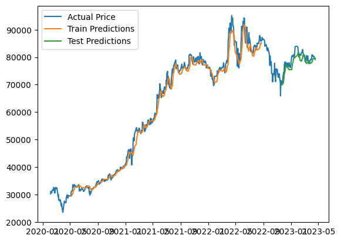

```python
# Visualize the results
import matplotlib.pyplot as plt
plt.plot(df_ma['Close'], label='Actual Price')
plt.plot(train_data.index[60:], train_predictions, label='Train Predictions')
plt.plot(test_data.index[60:], test_predictions, label='Test Predictions')
plt.legend()
plt.show()
```

As you can see, our prediction comes pretty close for both training and testing. Let's try to use the model to predict a future price.

```python
# Step 1: Get the last n_days days of data
n_days = 60
last_n_days = df_ma[-n_days:].values

# Step 2: Scale the input data
last_n_days_scaled = scaler.transform(last_n_days)

# Step 3: Reshape the input data
X_pred = last_n_days_scaled.reshape(1, n_days, 4)

# Step 4: Make predictions
predicted_scaled = model.predict(X_pred)

# Step 5: Inverse transform the predicted value
predicted_price = predicted_scaled[-1, 0] * (df['Close'].max() - df['Close'].min()) + df['Close'].min()

# Print the predicted price
print(f"The predicted price for the next day is: {predicted_price:.2f} VND")
```

```
The predicted price for the next day is: 78893.43 VND
```

[output not shown]